# Final Project

Jiaqi Li

Assigned: 12-14-2022

# The Economic Impact of Retail Mask Policies

On May 13, 2021, the Centers for Disease Control and Prevention (CDC) announced that people who have completed the New Crown Pneumonia vaccination are no longer required to wear masks in most settings and are no longer required to maintain social distance from others. Major retail brands have reacted quickly to this mask reversal policy, and several major supermarket chains and merchants, including Walmart, have already rescinded or re-evaluated their mask requirements. It is not difficult to infer that the change in mask policy would have a significant impact on consumer psychology and consumer behavior. Therefore, in this project, I start from this mask reversal and use the mask reversal implemented by Walmart on May 18 as a sample to study how changes in retail policies regarding mask use affect consumer behavior. At the same time, we will consider how factors such as vaccination hesitancy and partisanship will play into this impact.

The main elements of this project are as follows: In the fist part, I will introduce the raw data, do the basic processing, and also cover the basic exploratory data analysis. The second part is about the graphical exploratory data analysis. I will display some maps showing the location of Walmart stores in the county or state as an overview of the dataset. Several time series plots of the average foot traffic (by day) at Walmart stores over a 28-day period will be created to evaluate the effect of mask reversal policy. In the third part, I will use a multiple linear regression model to investigate specific impact of the reversal policy and further explores it by adding a series of mediating variables. Also, there will be some basic correlation analysis and plots.

```r
library(tidyverse)
library(ggplot2)
library(dplyr)
library(ggsignif)
library(usmap)
library(corrplot)
library(stargazer)
```

## Part 1. Data Processing and Basic Exploratory Data Analysis

### 1.2 Import Raw Dataset

```r
retail_fips <- read.csv("~/Desktop/GRADUATE/Semster2/R for Analytics/Project/Datasets/retail_data_export_w_fips.csv", stringsAsFactors=TRUE)
state_code <- read.csv("~/Desktop/GRADUATE/Semster2/R for Analytics/Project/Datasets/state_code.csv", stringsAsFactors=TRUE)
vote2020 <- read.csv("~/Desktop/GRADUATE/Semster2/R for Analytics/Project/Datasets/vote2020.csv", stringsAsFactors=TRUE)
county_week26_data_fixed <- read.csv("~/Desktop/GRADUATE/Semster2/R for Analytics/Project/Datasets/county_week26_data_fixed.csv", stringsAsFactors=TRUE)
```

### 1.3 Data Processing

```r
# Limit the periods of 28 days from 5.4-5.31
wal_data <- subset(retail_fips, dayofmonth >= 4 & dayofmonth <= 31)

# Mean process: (average_foot_traffic = mean of daily_visitors) to calculate the average number of daily_visitors for each day
retail_wal <- wal_data %>%
  group_by(dayofmonth) %>%
  summarize(
    count = n(),
    average_foot_traffic = mean(daily_visitors)
  )

# Combine the dataset
wal_state <- subset(wal_data, select = -c(fips))
wal <- left_join(wal_state,state_code,by="STATEFP")

# Merge the data - create the relationship between state name and statefp
vote2020_0 <- vote2020 %>%
  dplyr::select(county_fips,state_name)

retail_4 <- retail_fips %>%
  left_join(vote2020_0, by = c("fips" = "county_fips"))

plot_com <- retail_4 %>%
  group_by(state_name,dayofmonth) %>%
  summarize(mean_visitors = mean(daily_visitors))
# Prepare for boxplot and regression 1
retail_wal_2 <- retail_wal %>% mutate(post = if_else(dayofmonth > 17, 1, 0))
retail_fips <- retail_fips %>% mutate(post = if_else(dayofmonth > 17, 1, 0))

# Prepare for regression 2
# Subset our data, keeping only the columns we care about
vote2020_1 <- vote2020 %>%
  dplyr::select(county_fips,per_gop)

retail_new <- retail_fips %>%
  left_join(vote2020_1, by = c("fips" = "county_fips"))

# Add another variable
vaccine_hesitancy <- county_week26_data_fixed %>%
  dplyr::select(FIPS_Code,Estimated_hesitant)

retail_new <- retail_new %>%
  left_join(vaccine_hesitancy, by = c("fips" = "FIPS_Code"))

# Add dummy variable 1: trump
retail_new <- retail_new %>% mutate(trump = if_else(per_gop >= 0.5, 1, 0))

# Add dummy variable 2: vaccine_hes
# Seek for mean of vaccine hesitancy rate
VHM = mean(retail_new$Estimated_hesitant, na.rm = TRUE)
retail_new <- retail_new %>% mutate(vaccine_hes = if_else(Estimated_hesitant >= VHM, 1, 0))

# Correlation Analysis Preparation
retail_final <- subset(retail_new, select = c(daily_visitors,Estimated_hesitant,per_gop,post,trump,vaccine_hes,COUNTYFP,STATEFP))
```

### 1.4 Table Summary - Walmart Locations among States

```r
table_a <- sort(table(wal$state),decreasing = TRUE)
knitr::kable(table_a)
```

| Var1 | Freq |
| --- | --- |
| Texas | 14532 |
| Florida | 9604 |
| California | 7560 |
| North Carolina | 5404 |
| Georgia | 5264 |
| Illinois | 4424 |
| Ohio | 4032 |
| Missouri | 3892 |
| Tennessee | 3780 |
| Virginia | 3696 |
| Alabama | 3668 |
| Pennsylvania | 3584 |
| Louisiana | 3444 |
| Oklahoma | 3444 |
| Arkansas | 3304 |
| Indiana | 3164 |
| Arizona | 3108 |
| South Carolina | 2996 |
| New York | 2688 |
| Kentucky | 2576 |
| Michigan | 2548 |
| Colorado | 2520 |
| Wisconsin | 2464 |
| Mississippi | 2184 |
| Kansas | 2072 |
| Minnesota | 1876 |
| Washington | 1820 |
| New Jersey | 1708 |
| Iowa | 1624 |
| Utah | 1484 |
| Maryland | 1344 |
| Massachusetts | 1344 |
| New Mexico | 1288 |
| Nebraska | 1176 |
| Nevada | 1176 |
| Oregon | 1176 |
| West Virginia | 1092 |
| Connecticut | 924 |
| Puerto Rico | 756 |
| Idaho | 728 |
| New Hampshire | 728 |
| Maine | 616 |
| South Dakota | 420 |
| Montana | 392 |
| North Dakota | 364 |
| Wyoming | 336 |
| Hawaii | 280 |
| Delaware | 252 |
| Rhode Island | 252 |
| Alaska | 196 |
| Vermont | 168 |
| District of Columbia | 84 |

From the table we could see that the states with the most Walmart stores are Taxas, Florida, California. And Walmart is basically distributed nationwide, making it suitable as a study subject for policy evaluation.

### 1.5 Variables Overview

```r
str(retail_new)
```

```
## 'data.frame':    143437 obs. of  27 variables:
##  $ placekey          : Factor w/ 4627 levels "222-222@3x5-3f2-789",..: 1 1 1 1 1 1 1 1 1 1 ...
##  $ dayofmonth        : int  1 2 3 4 5 6 7 8 9 10 ...
##  $ daily_visitors    : int  58 72 58 46 62 72 54 63 60 81 ...
##  $ month             : int  5 5 5 5 5 5 5 5 5 5 ...
##  $ STATEFP           : int  53 53 53 53 53 53 53 53 53 53 ...
##  $ COUNTYFP          : int  63 63 63 63 63 63 63 63 63 63 ...
##  $ COUNTYNS          : int  1529225 1529225 1529225 1529225 1529225 1529225 1529225 1529225 1529225 1529225 ...
##  $ GEOID             : int  53063 53063 53063 53063 53063 53063 53063 53063 53063 53063 ...
##  $ NAME              : Factor w/ 1203 levels "Acadia","Accomack",..: 1007 1007 1007 1007 1007 1007 1007 1007 1007 1007 ...
##  $ NAMELSAD          : Factor w/ 1229 levels "Acadia Parish",..: 1026 1026 1026 1026 1026 1026 1026 1026 1026 1026 ...
##  $ LSAD              : int  6 6 6 6 6 6 6 6 6 6 ...
##  $ CLASSFP           : Factor w/ 4 levels "C7","H1","H4",..: 2 2 2 2 2 2 2 2 2 2 ...
##  $ MTFCC             : Factor w/ 1 level "G4020": 1 1 1 1 1 1 1 1 1 1 ...
##  $ CSAFP             : int  518 518 518 518 518 518 518 518 518 518 ...
##  $ CBSAFP            : int  44060 44060 44060 44060 44060 44060 44060 44060 44060 44060 ...
##  $ METDIVFP          : int  NA NA NA NA NA NA NA NA NA NA ...
##  $ FUNCSTAT          : Factor w/ 5 levels "A","B","C","F",..: 1 1 1 1 1 1 1 1 1 1 ...
##  $ ALAND             : num  4.57e+09 4.57e+09 4.57e+09 4.57e+09 4.57e+09 ...
##  $ AWATER            : num  43315180 43315180 43315180 43315180 43315180 ...
##  $ INTPTLAT          : num  47.6 47.6 47.6 47.6 47.6 ...
##  $ INTPTLON          : num  -117 -117 -117 -117 -117 ...
##  $ fips              : int  53063 53063 53063 53063 53063 53063 53063 53063 53063 53063 ...
##  $ post              : num  0 0 0 0 0 0 0 0 0 0 ...
##  $ per_gop           : num  0.503 0.503 0.503 0.503 0.503 ...
##  $ Estimated_hesitant: num  0.13 0.13 0.13 0.13 0.13 0.13 0.13 0.13 0.13 0.13 ...
##  $ trump             : num  1 1 1 1 1 1 1 1 1 1 ...
##  $ vaccine_hes       : num  0 0 0 0 0 0 0 0 0 0 ...
```

```r
summary(retail_new)
```

```
##                 placekey        dayofmonth daily_visitors       month
##  222-222@3x5-3f2-789:    31   Min.   : 1   Min.   :   0.0   Min.   :5
##  222-222@5nw-9rw-dy9:    31   1st Qu.: 8   1st Qu.:  94.0   1st Qu.:5
##  222-222@5nw-hmx-26k:    31   Median :16   Median : 148.0   Median :5
##  222-222@5nx-d48-dqf:    31   Mean   :16   Mean   : 163.8   Mean   :5
##  222-222@5nx-x3f-4vz:    31   3rd Qu.:24   3rd Qu.: 214.0   3rd Qu.:5
##  222-222@5ny-h2q-8qf:    31   Max.   :31   Max.   :1313.0   Max.   :5
##  (Other)            :143251                NA's   :2136
##     STATEFP         COUNTYFP         COUNTYNS           GEOID
##  Min.   : 1.00   Min.   :  1.00   Min.   :  23901   Min.   : 1001
##  1st Qu.:13.00   1st Qu.: 31.00   1st Qu.: 357722   1st Qu.:13067
##  Median :29.00   Median : 73.00   Median : 974128   Median :29009
##  Mean   :28.61   Mean   : 96.86   Mean   : 907142   Mean   :28707
##  3rd Qu.:45.00   3rd Qu.:121.00   3rd Qu.:1383910   3rd Qu.:45045
##  Max.   :72.00   Max.   :840.00   Max.   :2054176   Max.   :72137
##
##          NAME                     NAMELSAD           LSAD        CLASSFP
##  Jefferson :  1922   Maricopa County  :  1829   Min.   : 0.000   C7:  1457
##  Maricopa  :  1829   Orange County    :  1798   1st Qu.: 6.000   H1:135966
##  Orange    :  1798   Jefferson County :  1643   Median : 6.000   H4:  2201
##  Washington:  1581   Harris County    :  1550   Mean   : 6.468   H6:  3813
##  Harris    :  1550   Washington County:  1550   3rd Qu.: 6.000
##  Dallas    :  1364   Dallas County    :  1364   Max.   :25.000
##  (Other)   :133393   (Other)          :133703
##    MTFCC            CSAFP           CBSAFP         METDIVFP      FUNCSTAT
##  G4020:143437   Min.   :104.0   Min.   :10100   Min.   :11244    A:136276
##                 1st Qu.:206.0   1st Qu.:19140   1st Qu.:19124    B:   527
##                 Median :339.5   Median :30780   Median :23104    C:  2883
##                 Mean   :329.5   Mean   :29849   Mean   :28319    F:  1550
##                 3rd Qu.:426.0   3rd Qu.:39300   3rd Qu.:35614    N:  2201
##                 Max.   :566.0   Max.   :49780   Max.   :48864
##                 NA's   :47399   NA's   :13175   NA's   :125643
##      ALAND               AWATER             INTPTLAT        INTPTLON
##  Min.   :1.416e+07   Min.   :5.320e+04   Min.   :17.95   Min.   :-159.71
##  1st Qu.:1.273e+09   1st Qu.:1.648e+07   1st Qu.:33.02   1st Qu.: -97.29
##  Median :1.842e+09   Median :4.336e+07   Median :36.17   Median : -88.46
##  Mean   :3.368e+09   Mean   :2.376e+08   Mean   :36.43   Mean   : -91.51
##  3rd Qu.:2.643e+09   3rd Qu.:1.881e+08   3rd Qu.:40.35   3rd Qu.: -81.69
##  Max.   :6.373e+10   Max.   :4.891e+09   Max.   :64.69   Max.   : -65.59
##
##       fips            post           per_gop       Estimated_hesitant
##  Min.   : 1001   Min.   :0.0000   Min.   :0.0540   Min.   :0.0600
##  1st Qu.:13067   1st Qu.:0.0000   1st Qu.:0.4228   1st Qu.:0.1500
##  Median :29009   Median :0.0000   Median :0.5354   Median :0.1800
##  Mean   :28707   Mean   :0.4516   Mean   :0.5385   Mean   :0.1787
##  3rd Qu.:45045   3rd Qu.:1.0000   3rd Qu.:0.6620   3rd Qu.:0.2100
##  Max.   :72137   Max.   :1.0000   Max.   :0.9035   Max.   :0.3200
##                                   NA's   :1054     NA's   :837
##      trump         vaccine_hes
##  Min.   :0.0000   Min.   :0.0000
##  1st Qu.:0.0000   1st Qu.:0.0000
##  Median :1.0000   Median :1.0000
##  Mean   :0.5595   Mean   :0.5233
##  3rd Qu.:1.0000   3rd Qu.:1.0000
##  Max.   :1.0000   Max.   :1.0000
##  NA's   :1054     NA's   :837
```

#### Variable Introduction

The data includes 143,437 observations on 27 variables, including May 2021 Walmart store foot traffic and related campaign and vaccination data. Some of the key variables are as follows.

1. dayofmonth: Day of month in May, 2021.
2. daily_visitors: Daily visitors to Walmart.
3. STATEFP: Fip code of the state.
4. COUNTYFP: County fip code.
5. fips. fip code.
6. post: This variable equals to 0 before the policy change and equals to 1 after the policy change.
7. per_gop: Republican approval rating.
8. Estimated_hesitant: Estimated hesitancy to vaccinate, unwillingness or refusal to have oneself or one’s child vaccinated.
9. trump: Measure of support for Trump to take office, this variable equals 1 if the Republican approval rating is higher than 0.5, and 0 if not.
10. vaccine_hes: Measures whether vaccine hesitancy is higher than the mean, if vaccine hesitancy is higher than the mean then this variable equals 1, otherwise it equals 0.

## Part 2. Graphical EDA

### 2.1 Overall Review

#### (1) Daily Visitor of Walmart Stores by County

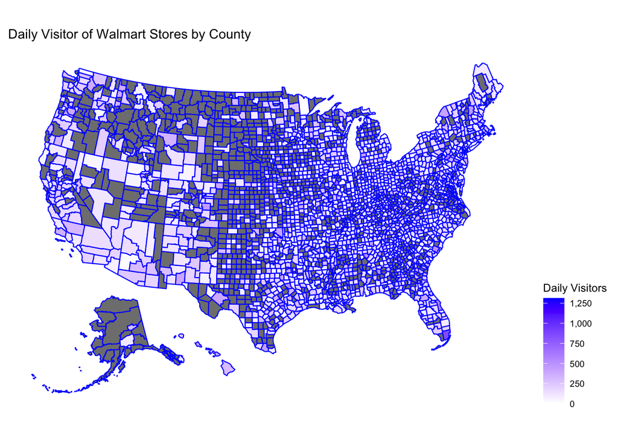

```r
plot_usmap(data = wal_data, values = "daily_visitors", color="blue") +
  scale_fill_continuous(low = "white", high = "blue", name = "Daily Visitors", label = scales::comma) +
  theme(legend.position = "right") +
  labs(title = "Daily Visitor of Walmart Stores by County")
```

In terms of counties, Walmart is located in almost every county in the U.S., and traffic is more intense in the east than in the west.

#### (2) Daily Visitor of Walmart Stores by State

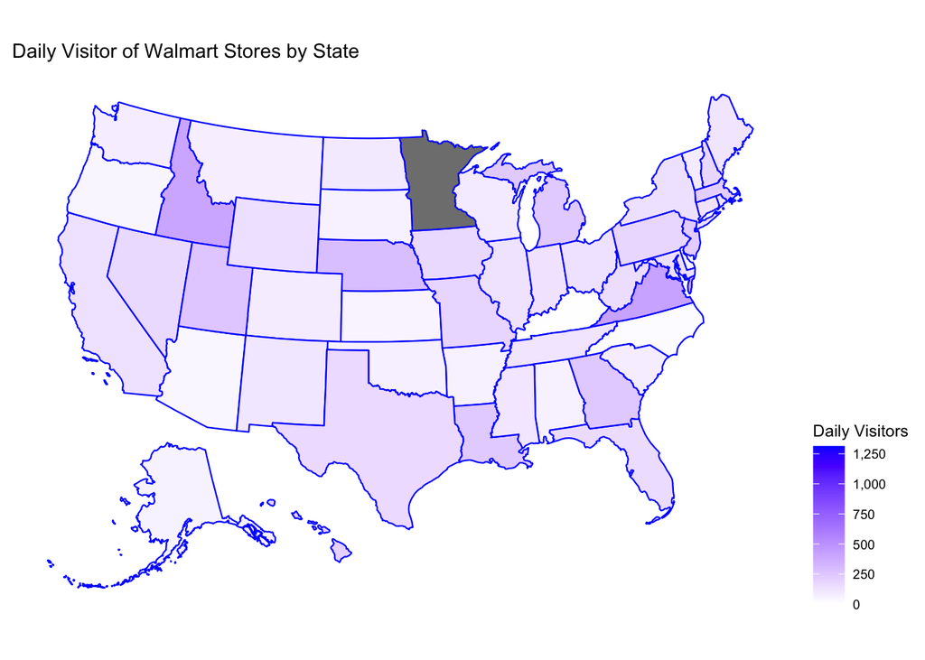

```r
plot_usmap(data = wal, values = "daily_visitors", color = "blue") +
  scale_fill_continuous(low = "white", high = "blue", name = "Daily Visitors", label = scales::comma) +
  labs(title = "Daily Visitor of Walmart Stores by State") +
  theme(legend.position = "right")
```

On a state-by-state basis, customer traffic varies slightly between states, but the differences are not so significant.

### 2.2 Change Analysis

#### (1) Line Plot

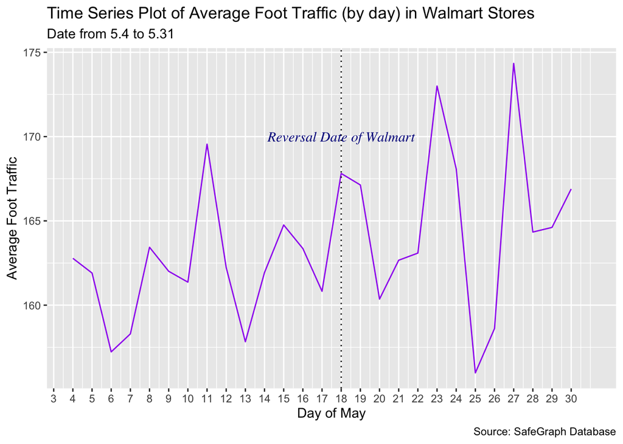

```r
# Depict the line plot
walmart <- ggplot(retail_wal, aes(x=dayofmonth, y=average_foot_traffic))

walmart +
  geom_line(aes(x= dayofmonth , y= average_foot_traffic ), color="purple") +
  labs(title = "Time Series Plot of Average Foot Traffic (by day) in Walmart Stores",subtitle = "Date from 5.4 to 5.31",x = "Day of May",y = "Average Foot Traffic",caption="Source: SafeGraph Database") +
  scale_x_continuous(breaks=seq(0,30,1)) +
  geom_vline(xintercept=c(18), linetype="dotted") +
  annotate("text", x=18, y=170, label="Reversal Date of Walmart", family="serif",fontface="italic", colour="darkblue", size=4)
```

As seen in graph above, on May 18, Walmart began to implement the reversal policy, and there was a clear change in the level of Walmart guest traffic before and after the policy was withdrawn: customer traffic showed an overall upward trend with the liberalization of the mask restriction, peaking at higher levels on the 23rd and 27th, and the trend continues, albeit with significant fluctuations. For the retail business and FMCG industry, this phenomenon makes sense: customers value not only the consumer product itself, but also many other factors such as service quality, consumer environment, etc. With the relaxation of the mask policy, consumers are likely to feel more relaxed and comfortable in the service atmosphere, have a higher degree of autonomy in their choices, and are therefore more likely to choose to go out shopping.

#### (2) Boxplot

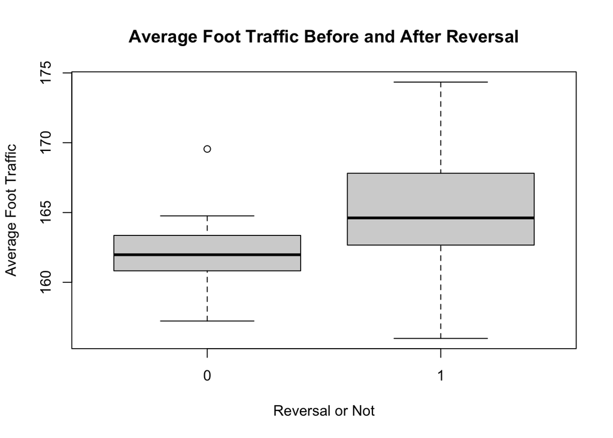

```r
# Boxplot Analysis
boxplot(retail_wal_2$average_foot_traffic ~ retail_wal_2$post, main="Average Foot Traffic Before and After Reversal", xlab="Reversal or Not", ylab="Average Foot Traffic")
```

The graph above shows the change in traffic before and after reversal more significantly, and it can be seen that the mean value of traffic increased overall and the maximum value also increased after the implementation of the mask reversal policy. This indicates that the reversal policy has a significant effect on the promotion of traffic. Of course, there may be other variables that have an effect, and the significance of this effect will be further demonstrated in the following section.

#### (3) Time Series Plot

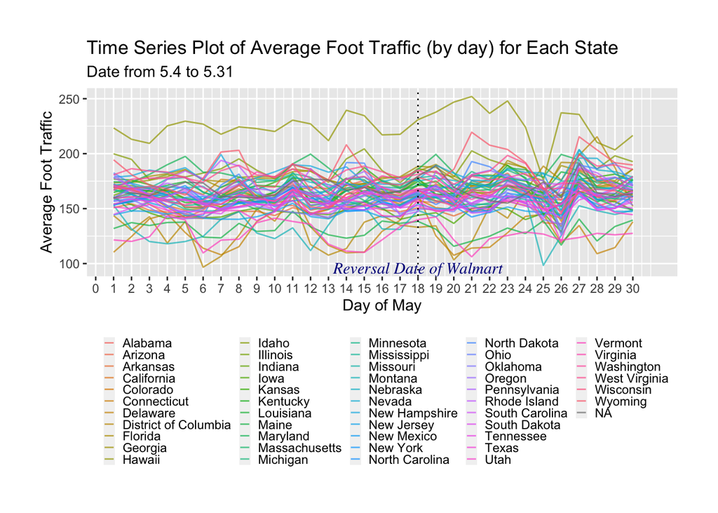

```r
# Depict the plot
ggplot(plot_com)+geom_line(aes(x = dayofmonth, y = mean_visitors, group = state_name,color = factor(state_name) ), alpha = 0.7)+labs(title = "Time Series Plot of Average Foot Traffic (by day) for Each State",subtitle = "Date from 5.4 to 5.31",x = "Day of May",y = "Average Foot Traffic")+scale_x_continuous(breaks=seq(0,30,1))+geom_vline(xintercept=c(18), linetype="dotted")+annotate("text", x=18, y=96, label="Reversal Date of Walmart", family="serif",fontface="italic", colour="darkblue", size=4)+guides(color=guide_legend(title=NULL))+theme(legend.key.size = unit(8, "pt"), plot.margin=unit(rep(1,5),'cm'), legend.position = "bottom")
```

In this section, I visualized the daily data from different states to more visually observe the regionalized impact of the mask policy on consumer behavior and the overall impact. As can be seen in this figure, there is a more significant increase in customer visits in most states before and after the reversal date. We also note that there is a significant difference in customer baseline across states, with visits significantly higher in Hawaii than in other states. In terms of time, there are also significant differences by date, and there is a similar trend across states. Therefore, in the third part of the regression analysis, I selected individual and time fixed effects models to eliminate the effect of individual and time differentiation on the results.

## Part 3. Correlation Analysis

### 3.1 Correlation Analysis

```r
retail_cor <- cor(retail_final, use = "complete.obs")
retail_cor
```

```
##                    daily_visitors Estimated_hesitant       per_gop         post
## daily_visitors        1.000000000        0.023542314 -0.0070479804 0.0180949189
## Estimated_hesitant    0.023542314        1.000000000  0.4593211325 0.0014738445
## per_gop              -0.007047980        0.459321133  1.0000000000 0.0009254191
## post                  0.018094919        0.001473844  0.0009254191 1.0000000000
## trump                -0.006371872        0.401644259  0.8305718807 0.0010756245
## vaccine_hes           0.037491164        0.786494771  0.3875627385 0.0009744323
## COUNTYFP              0.011233925        0.075762775  0.0895358303 0.0006593772
## STATEFP              -0.015912568       -0.039795498  0.0979652621 0.0003994112
##                           trump   vaccine_hes      COUNTYFP       STATEFP
## daily_visitors     -0.006371872  0.0374911636  0.0112339250 -0.0159125682
## Estimated_hesitant  0.401644259  0.7864947707  0.0757627746 -0.0397954977
## per_gop             0.830571881  0.3875627385  0.0895358303  0.0979652621
## post                0.001075624  0.0009744323  0.0006593772  0.0003994112
## trump               1.000000000  0.3504142889  0.0286271743  0.0944034463
## vaccine_hes         0.350414289  1.0000000000 -0.0078712340 -0.1581672148
## COUNTYFP            0.028627174 -0.0078712340  1.0000000000  0.2831507653
## STATEFP             0.094403446 -0.1581672148  0.2831507653  1.0000000000
```

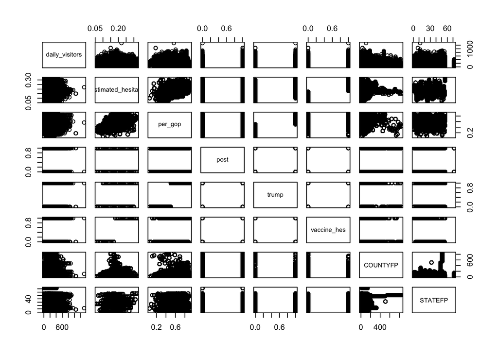

```r
pairs(retail_final)
```

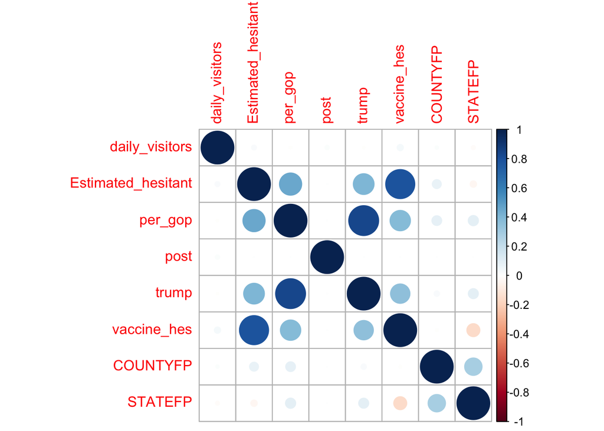

```r
corrplot(retail_cor)
```

Here I performed the basic correlation test and it can be seen that there is some correlation in the key variables, and I will try to select independent variables for the subsequent study. In addition, it can be seen that the key variable POST is not significantly correlated with other variables, which lays a good foundation for the subsequent study.

## Part 4. Regression Analysis

### 4.2 Regression Model 1: Basic Regression with post

Note: The description section includes only explanations of models with fixed effects; models without fixed effects are only compared in order to demonstrate the validity of fixed effects.

```r
# Run the regression (1)
reg_model_lm1 <- lm(daily_visitors ~ post, data = retail_fips )
# Add the fixed effect: the regression model (2)
reg_model_lm2 <- lm(daily_visitors ~ post+ factor(STATEFP) + factor(dayofmonth), data = retail_fips)
# Summary
stargazer(reg_model_lm1, reg_model_lm2, omit = c("STATEFP","dayofmonth"), type="text")
```

```
##
## ==========================================================================
##                                      Dependent variable:
##                     ------------------------------------------------------
##                                         daily_visitors
##                                (1)                         (2)
## --------------------------------------------------------------------------
## post                         3.524***                   17.156***
##                              (0.520)                     (2.398)
##
## Constant                    162.229***                 157.267***
##                              (0.346)                     (2.066)
##
## --------------------------------------------------------------------------
## Observations                 141,301                     141,301
## R2                            0.0003                      0.013
## Adjusted R2                   0.0003                      0.012
## Residual Std. Error    97.047 (df = 141299)       96.480 (df = 141219)
## F Statistic         45.986*** (df = 1; 141299) 22.155*** (df = 81; 141219)
## ==========================================================================
## Note:                                          *p<0.1; **p<0.05; ***p<0.01
```

As seen in the results of regression (2) , the coefficient of the variable of post is 17.1559, which is significant at the 1% level of significance, indicating that there is a large increase in consumer visits after the withdrawal of the retail mask policy and that this effect is significant. However, there is a serious omitted variable bias in this regression and there may be an interaction effect, so we added other variables.

### 4.3 Regression Model 2: Adding Interactions

Considering that the effect of mask policy on consumer behavior may depend on the values of other variables, I included interactions in the model in this part. In this way, I could better answer the question about how the effect of the policy reversal differed in counties that are more Republican or with higher vaccine hesitancy. I also added interaction terms to evaluate whether these two effects differ from each other.

Note: In this section, I only show the results of the models with fixed effects and the models without fixed effects are shown separately at the end of this section.

```r
# Run the regression (1)
reg_1 <- lm(daily_visitors ~ post + post:trump, data = retail_new)
# Run the regression (2): regression (1) + fixed effect
reg_1_f<- lm(daily_visitors ~ post + post:trump + factor(STATEFP)+factor(dayofmonth), data = retail_new)

# Run the regression (3)
reg_2 <- lm(daily_visitors ~ post + post:vaccine_hes, data = retail_new)
# Run the regression (4): regression (3) + fixed effect
reg_2_f<- lm(daily_visitors ~ post + post:vaccine_hes + factor(STATEFP)+factor(dayofmonth), data = retail_new)

# Run the regression (5)
reg_3 <- lm(daily_visitors ~ post + post:vaccine_hes + post:trump, data = retail_new)
# Run the regression (6): regression (5) + fixed effect
reg_3_f<- lm(daily_visitors ~ post + post:vaccine_hes + post:trump + factor(STATEFP)+factor(dayofmonth), data = retail_new)

# Summary
stargazer(reg_1_f, reg_2_f, reg_3_f, omit = c("STATEFP","dayofmonth"), type="text")
```

```
##
## =======================================================================================================
##                                                     Dependent variable:
##                     -----------------------------------------------------------------------------------
##                                                       daily_visitors
##                                 (1)                         (2)                         (3)
## -------------------------------------------------------------------------------------------------------
## post                         17.195***                   13.850***                   14.646***
##                               (2.449)                     (2.451)                     (2.476)
##
## post:trump                    -0.279                                                 -2.105**
##                               (0.817)                                                 (0.857)
##
## post:vaccine_hes                                         5.999***                    6.730***
##                                                           (0.916)                     (0.963)
##
## Constant                    157.354***                  156.071***                  156.144***
##                               (2.072)                     (2.079)                     (2.079)
##
## -------------------------------------------------------------------------------------------------------
## Observations                  140,278                     140,490                     140,278
## R2                             0.013                       0.013                       0.013
## Adjusted R2                    0.012                       0.012                       0.012
## Residual Std. Error    96.500 (df = 140197)        96.499 (df = 140408)        96.484 (df = 140196)
## F Statistic         22.364*** (df = 80; 140197) 22.685*** (df = 81; 140408) 22.700*** (df = 81; 140196)
## =======================================================================================================
## Note:                                                                       *p<0.1; **p<0.05; ***p<0.01
```

In regressions (1) and (2), I included the interaction terms: post`*`trump_vs and post`*`vaccine_hes. Because of the need to examine the dependence of the impact of the mask policy on the high level of Republican support and vaccine hesitancy, I generated two dummy variables for the regressions, respectively. From regression result (1), the coefficient of the variable of post is 17.1949, which is significant at 1% level of significance, but the interaction term of post`*`trump_vs is not significant. From regression result (2), the coefficient of the variable of post is 13.8497, which is significant at the 1% level of significance. The coefficient of the interaction term post`*`vaccine_hes is 5.9991, which is significant at the 1% level of significance. From these results, it is clear that the effect has a low dependence on partisan support and a high and significant dependence on vaccine hesitancy. Interestingly, the two interaction terms have opposite directions of effect on the effect of mask policy, which is also verified in the next regression.

Indeed, there is an effect of partisan bias on the population’s wearing of masks, and this finding has been verified to some extent in the existing literature. A study by political science experts at the University of Pennsylvania (Gadarian et al, 2020) suggests that whether people are Democratic or Republican supporters has more influence on the strategies they adopt in response to the outbreak, such as keeping social distance and wearing masks, compared to the severity of the outbreak. The study points out that partisanship does not only represent the views of individual political behavior, such as voting, but is a fairly stable set of emotional orientations, social values and identities that profoundly influence the psychological and behavioral states of the American public, including attitudes and actions in response to the epidemic. The results of the study point out that epidemic-proofing behaviors such as wearing a mask or maintaining social distance are influenced by partisan affiliation 138 times more than the severity of the epidemic. Furthermore, in the United States, the Republican Party is generally considered to be a conservative party with a conservative classical economist approach to government, and therefore the decision-making behavior of its party supporters is also somewhat conservative, so that despite the withdrawal of the mask policy by retail brands, these consumers may instead reduce their store visits due to safety concerns, and therefore the impact is negative.

In addition, vaccine hesitation is not uncommon in the United States. According to GlobeNewswire, a large number of Americans are now skeptical about receiving the new vaccine crown, and CNN has published an article saying that there is a “vaccine hesitation” in the U.S., which simply means that people are still skeptical about vaccination, mainly because they are worried about the effectiveness and safety of the vaccine. States with a higher degree of vaccine hesitancy may have a higher degree of free will to decide on their own whether to vaccinate or wear a mask. In such a case, with the implementation of the mask policy reversal, these states may be more willing to enter the retail market for consumption.

#### Models without fixed effects

```r
stargazer(reg_1, reg_2, reg_3, omit = c("STATEFP","dayofmonth"), type="text")
```

```
##
## ====================================================================================================
##                                                   Dependent variable:
##                     --------------------------------------------------------------------------------
##                                                      daily_visitors
##                                (1)                        (2)                        (3)
## ----------------------------------------------------------------------------------------------------
## post                         4.520***                    -0.229                    1.635**
##                              (0.682)                    (0.662)                    (0.734)
##
## post:trump                   -1.754**                                             -4.860***
##                              (0.784)                                               (0.837)
##
## post:vaccine_hes                                        7.175***                   8.837***
##                                                         (0.779)                    (0.831)
##
## Constant                    162.194***                 162.217***                 162.194***
##                              (0.347)                    (0.347)                    (0.347)
##
## ----------------------------------------------------------------------------------------------------
## Observations                 140,278                    140,490                    140,278
## R2                            0.0004                     0.001                      0.001
## Adjusted R2                   0.0003                     0.001                      0.001
## Residual Std. Error    97.070 (df = 140275)       97.056 (df = 140487)       97.031 (df = 140274)
## F Statistic         25.475*** (df = 2; 140275) 65.418*** (df = 2; 140487) 54.656*** (df = 3; 140274)
## ====================================================================================================
## Note:                                                                    *p<0.1; **p<0.05; ***p<0.01
```

## Part 5. Conclusions

During a pandemic, it is important to study consumer behavior in response to mask policies, whether for retailers to anticipate consumer reactions to better implement necessary policies (provided they are safe), or for the CDC or national level to implement key policies. The impact of retailers’ mask policies on consumers is evident from this study, so it is important for retailers to consider the practical implications and possible impact of their policies and to provide feedback based on the development of the epidemic. The same is true for the NCDC. In addition, the impact should take into account other factors, such as the demographic profile of each state, vaccine hesitancy, and partisan support.